# Confidence Intervals Homework

### NAMES: Eitan Lees, Susannah Hogue, Tyler Davis — Partial Solution

*This is entirely our own work except as noted at the end of the document.*

**Due No Later than 5pm, November 15, 2012**

```
[1] "2012-11-15 13:51:50 EST"
```

**Prob1** - Import the data set `Spruce` into `R`.

```r
Spruce <- importData("Spruce")
head(Spruce)
```

```
  Tree Competition Fertilizer Height0 Height5 Diameter0 Diameter5
1    1          NC          F    15.0    60.0     1.984       7.4
2    2          NC          F     9.0    45.2     1.191       5.2
3    3          NC          F    12.0    42.0     1.786       5.7
4    4          NC          F    13.7    49.5     1.587       6.4
5    5          NC          F    12.0    47.3     1.587       6.2
6    6          NC          F    12.0    56.4     1.587       7.4
  Ht.change Di.change
1      45.0     5.416
2      36.2     4.009
3      30.0     3.914
4      35.8     4.812
5      35.3     4.613
6      44.4     5.812
```

- Create exploratory plots to check the distribution of the variable `Ht.change`.

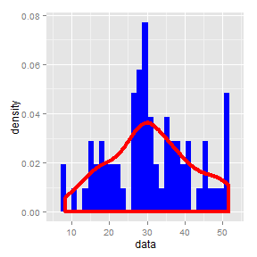

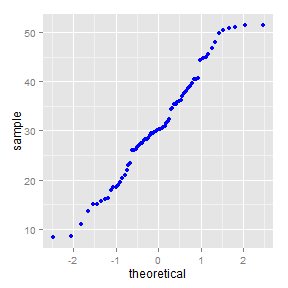

```r
EDA.hist(Spruce$Ht.change)
EDA.qq(Spruce$Ht.change)
```

The data has an approximately normal distribution.

- Find a 95% \( t \) confidence interval for the mean height change over the 5-year period of the study and give a sentence interpreting your interval.

> SOLUTION:

```r
spruce_t <- t.test(Spruce$Ht.change)
```

We are 95% confident that the change in height for a spruce tree in a 5 year period is within (`28.3368`, `33.5298`).

- Create exploratory plots to compare the distributions of the variable `Ht.change` for the seedlings in the fertilized and nonfertilized plots.

**With Fertilizer**

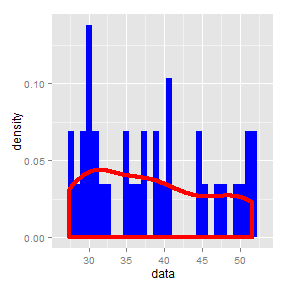

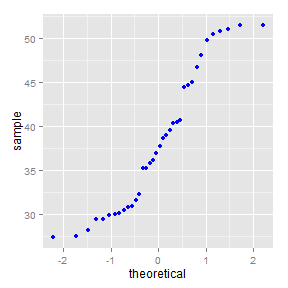

```r
EDA.hist(Spruce$Ht.change[Spruce$Fertilizer == "F"])
EDA.qq(Spruce$Ht.change[Spruce$Fertilizer == "F"])
```

**Without Fertilizer**

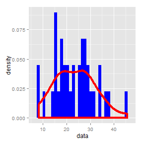

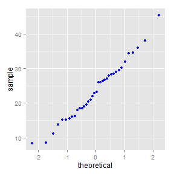

```r
EDA.hist(Spruce$Ht.change[Spruce$Fertilizer != "F"])
EDA.qq(Spruce$Ht.change[Spruce$Fertilizer != "F"])
```

- Find the 95% one-sided lower \( t \) confidence bound for the difference in mean heights (\( \mu_F - \mu_{NF} \)) over the 5-year period of the study and give a sentence interpreting your interval.

> SOLUTION:

```r
spruce_t2 <- t.test(Spruce$Ht.change ~ Spruce$Fertilizer, alternative = "greater")
```

We are 95% confident that the difference in heights between spruce trees that were fertilized and those that were not during a 5 year period is at least `11.4666`.

**Prob2** - Consider the data set `Girls2004` with birth weights of baby girls born in Wyoming or Alaska.

- Create exploratory plots and compare the distribution of weight between the babies born in the two states.

```r
Girls <- importData("Girls2004")
head(Girls)
```

```
  ID State MothersAge Smoker Weight Gestation
1  1    WY      15-19     No   3085        40
2  2    WY      35-39     No   3515        39
3  3    WY      25-29     No   3775        40
4  4    WY      20-24     No   3265        39
5  5    WY      25-29     No   2970        40
6  6    WY      20-24     No   2850        38
```

> SOLUTION:

**Wyoming**

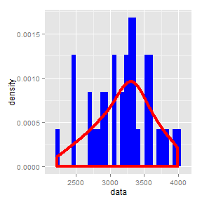

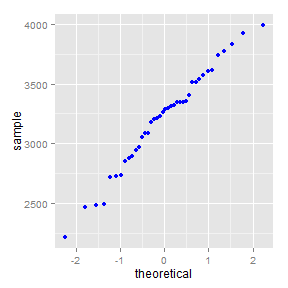

```r
EDA.hist(Girls$Weight[Girls$State == "WY"])
EDA.qq(Girls$Weight[Girls$State == "WY"])
```

**Alaska**

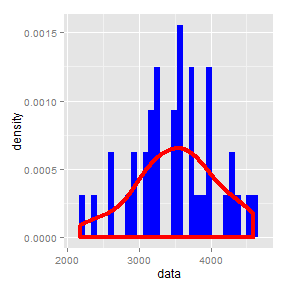

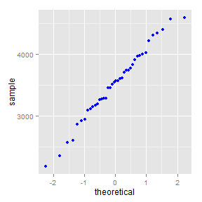

```r
EDA.hist(Girls$Weight[Girls$State == "AK"])
EDA.qq(Girls$Weight[Girls$State == "AK"])
```

- Find a 95% \( t \) confidence interval for the mean difference in weights for girls born in these two states. Give a sentence interpreting this interval.

> SOLUTION:

```r
girls_t <- t.test(Girls$Weight[Girls$State == "AK"], Girls$Weight[Girls$State ==
    "WY"])
```

We are 95% confident that the difference in weights between girls born in Wyoming and girls born in Alaska is within (`83.294`, `533.606`).

- Create exploratory plots and compare the distribution of weights between babies born to nosmkokers and babies born to smokers.

**Smokers**

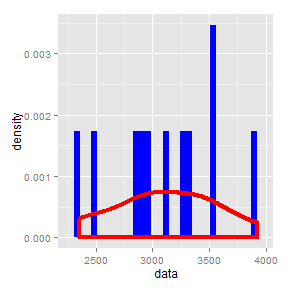

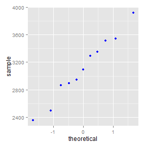

```r
EDA.hist(Girls$Weight[Girls$Smoker == "Yes"])
EDA.qq(Girls$Weight[Girls$Smoker == "Yes"])
```

**Non-Smokers**

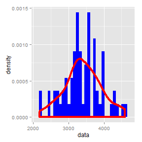

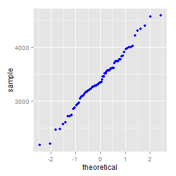

```r
EDA.hist(Girls$Weight[Girls$Smoker == "No"])
EDA.qq(Girls$Weight[Girls$Smoker == "No"])
```

- Find a 95% \( t \) confidence interval for the difference in mean weights between babies born to nonsmokers and smokers. Give a sentence interpreting this interval.

> SOLUTION:

```r
girls_t2 <- t.test(Girls$Weight[Girls$Smoker == "Yes"], Girls$Weight[Girls$Smoker ==
    "No"])
```

We are 95% confident that the difference in weights between girls born to smokers and girls born to non-smokers is within (`-617.9197`, `44.033`).

**Prob3** - Import the `FlightDelays` data set into `R`. Although the data represent all flights for United Airlines and American Airlines in May and June 2009, assume for this exercise that these flights are a sample from all flights flown by the two airlines under similar conditions. We will compare the lengths of flight delays betwen the two airlines.

```r
Flight <- importData("FlightDelays")
head(Flight)
```

```
  ID Carrier FlightNo Destination DepartTime Day Month FlightLength Delay
1  1      UA      403         DEN      4-8am Fri   May          281    -1
2  2      UA      405         DEN     8-Noon Fri   May          277   102
3  3      UA      409         DEN      4-8pm Fri   May          279     4
4  4      UA      511         ORD     8-Noon Fri   May          158    -2
5  5      UA      667         ORD      4-8am Fri   May          143    -3
6  6      UA      669         ORD      4-8am Fri   May          150     0
  Delayed30
1        No
2       Yes
3        No
4        No
5        No
6        No
```

- Create exploratory plots of the lengths of delays for the two airlines.

**United Airlines**

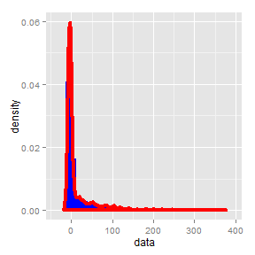

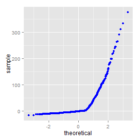

```r
EDA.hist(Flight$Delay[Flight$Carrier == "UA"])
EDA.qq(Flight$Delay[Flight$Carrier == "UA"])
```

**American Airlines**

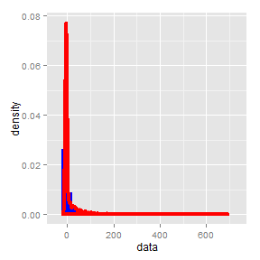

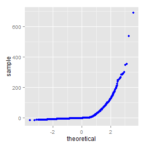

```r
EDA.hist(Flight$Delay[Flight$Carrier == "AA"])
EDA.qq(Flight$Delay[Flight$Carrier == "AA"])
```

- Find a 95% \( t \) confidence interval for the difference in mean flight delays between the two airlines and interpret this interval.

> SOLUTION:

```r
flight_t <- t.test(Flight$Delay[Flight$Carrier == "UA"], Flight$Delay[Flight$Carrier ==
    "AA"])
```

We are 95% confident that the difference in delay times between United Airlines and American Airlines is within (`2.8682`, `8.9032`).

**Prob4** - Run a simulation to see if the \( t \) ratio \( T = (\bar{X} -\mu)/(S/\sqrt{n}) \) has a \( t \) distribution or even an approximate \( t \) distirubiton when the samples are drawn from a nonnormal distribution. Be sure to superimpose the appropriate \( t \) density curve over the density of your simulated \( T \). Try two different nonnormal distributions \( \left( Unif(a = 0, b = 1), Exp(\lambda = 1) \right) \) and remember to see if sample size makes a difference (use \( n = 15 \) and \( n=500 \)).

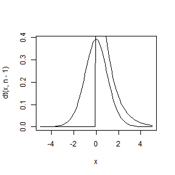

```r
########################## HELP!!!! ################################
n <- 15
mu <- 0
N <- rexp(n)
# Tb <- mean(N)-mu/sqrt(n)
curve(dt(x, n - 1), -5, 5)
curve(dexp(x, 1), add = T)
########################## HELP!!!! ################################
```

**Prob5** - One question is the 2002 General Social Survey asked participants whom they voted for in the 2000 election. Of the 980 women who voted, 459 voted for Bush. Of the 759 men who voted, 426 voted for Bush.

- Find a 95% confidence interval for the proportion of women who voted for Bush.

> SOLUTION: We are 95% confident that the proportion of women who voted for Bush from the 2002 General Social Survey is within (`0.4368`, `0.5002`)
- Find a 95% confidence interval for the proportion of men who voted for Bush. Do the intervals for the men and women overlap? What, if anything, can you conclude about gender difference in voter preference?

> SOLUTION: We are 95% confident that the proportion of men who voted for Bush from the 2002 General Social Survey is is within (`0.5251`, `0.5968`). The intervals for the proportion of men who voted for Bush and the proportion of women who voted for Bush do not overlap but since we tested the proportion of means seperately, we cannot conclude anything about their apparent difference. To be able to conclude something, we would need to test a difference of proportions explicitly.

**Prob6** - A retail store wishes to conduct a marketing survey of its customers to see if customers would favor longer store hours. How many people should be in their sample if the marketers want their margin of error to be at most 3% with 95% confidence, assuming

- they have no preconceived idea of how customers will respond, and

```r
error <- 0.03
p_sqiggle <- 0.5
sample_size <- ceiling((p_sqiggle * (1 - p_sqiggle))/(error/1.96)^2)
```

> SOLUTION: To provide a confidenced level of 95% and a margin of error of a maximum 3%, the marketers should get responses from a minimum `1068` people.
- a previous survey indicated that about 65% of customers favor longer store hours.

```r
p_sqiggle <- 0.65
sample_size <- ceiling((p_sqiggle * (1 - p_sqiggle))/(error/1.96)^2)
```

> SOLUTION: Given the knowledge of the survey where 65% of respondants favored longer hours, the store should use a sample size of `972` people.

**Prob7** - Suppose researchers wish to study the effectiveness of a new drug to alleviate hives due to math anxiety. Seven hundred math students are randomly assigned to take either this drug or a placebo. Suppose 34 of the 350 students who took the drug break out in hives compared to 56 of the 350 students who took the placebo.

- Compute a 95% confidence interval for the proportion of students taking the drug who break out in hives.

```r
test <- prop.test(34, 350)
```

> SOLUTION: We are 95% confident that the proportion of students taking the drug who break out in hives is within (`0.0691`, `0.1343`)
- Compute a 95% confidence interval for the proportion of students taking the placebo who break out in hives.

```r
test <- prop.test(56, 350)
```

> SOLUTION: We are 95% confident that the proportion of students taking the placebo who break out in hives is within (`0.124`, `0.2036`)
- Do the intervals overlap? What, if anything, can you conclude about the effectiveness of the drug?

> SOLUTION: Despite the intervals overlapping, we cannot conclude anything.
- Compute 95% confidence interval for the difference in proportions of students who break out in hives by using or not using this drug and give a sentence interpreting this interval.

```r
x <- c(34, 56)
n <- c(350, 350)
test <- prop.test(x, n)
```

> SOLUTION: We are 95% confident that the difference in the proportion of students taking the placebo who break out in hives to the proportion ofstudents taking the placebo who break out in hives is within (`-0.1151`, `-0.0106`). Since zero is not included in the interval we have sufficient statistical evidence to reject the null hypothesis that the drug and the placebo will effect the student with equal probability.

**Prob8** - An article in the March 2003 *New England Journal of Medicine* describes a study to see if aspirin is effective in reducing the incidence of colorectal adenomas, a precursor to most colorectal cancers (Sandler et al. (2003)). Of 517 patients in the study, 259 were randomly assigned to receive aspirin and the remaining 258 received a placebo. One or more adenomas were found in 44 of the aspirin group and 70 in the placebo group. Find a 95% one-sided upper bound for the difference in proportions \( (p_A - p_P) \) and interpret your interval.

```r
x <- c(44, 70)
n <- c(259, 258)
test <- prop.test(x, n, alternative = "less")
```

> SOLUTION: We are 95% confident that the difference in adenomas found in the aspirin group and the placebo group is less than or equal to `-0.038`.

**Prob9** - The data set `Bangladesh` has measurements on water quality from 271 wells in Bangladsesh. There are two missing values in the chlorine variable. Use the following `R` code to remove these two observations.

`> chlorine <- with(Bangladesh, Chlorine[!is.na(Chlorine)])`

```r
Banga <- importData("Bangladesh")
chlorine <- with(Banga, Chlorine[!is.na(Chlorine)])
```

- Compute the numeric summaries of the cholorine levels and create a plot and comment on the distribution.

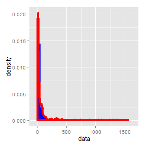

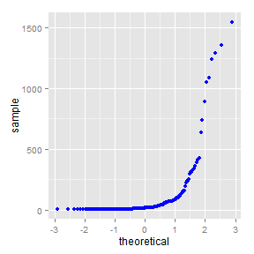

```r
EDA.hist(chlorine)
EDA.qq(chlorine)
```

```r
test <- t.test(chlorine)
```

> SOLUTION: We are 95% confident that the mean \( \mu \) of chlorine levels in Bangladesh wells is within (`52.8726`, `103.2954`).
- Find a 95% bootstrap percentile and bootstrap \( t \) confidence intervals for the mean chlorine level and compare results. Which confidence interval will you report?

```r
test <- tboot(chlorine)
test
```

```
      boot.conf percentile.conf
97.5%     56.43           54.66
2.5%     112.28          105.39
```

> SOLUTION: We would report the bootstrap confidence interval (`56.4291, 112.278`) because it accounts for skewness.
- *Johnson's \( t \) confidence interval* adjusts for skewness by shifting endpoints right or left for positive or negative skewness, respectively. The interval is \( \bar{X} + \hat{\kappa_3}/(6\sqrt{n})(1 + 2q^2) \pm q(S/\sqrt{n}) \), where \( \hat{\kappa_3} \) is a sample estimate of the population skewness \( E(X - \mu)/\sigma^3 \) and \( q \) denotes the \( 1 - \alpha/2 \) quantile for a \( t \) distribution with \( n-1 \) degrees of freedom. Calculate Johnson's \( t \) interval for the arsenic data (in `Bangladesh`) and compare with the formula \( t \) and bootstrap \( t \) intervals.

```r
skew <- skewness(Banga$Arsenic, na.rm = T)
test <- tboot(Banga$Arsenic)
```

**Prob10** - The data set `MnGroundwater` has measurements on water quality of 895 randomly selected wells in Minnesota.

```r
Water <- importData("MnGroundwater")
head(Water)
```

```
  County        Aquifer.Group Water.Level Alkalinity Aluminum Arsenic
1 Aitkin surficial Quaternary          55     137000    0.059   1.810
2 Aitkin    buried Quaternary          30     214000    2.380   0.059
3 Aitkin    buried Quaternary          20     120000    0.410   1.440
4 Aitkin    buried Quaternary           3     283000  158.190   6.340
5 Aitkin    buried Quaternary           0     236000    0.059  10.170
6 Aitkin    buried Quaternary          30     229000    0.059   6.900
  Chloride Lead  pH              Basin.Name
1      490 0.17 7.1 Upper Mississippi River
2    89250 0.18 7.6 Upper Mississippi River
3      300 0.52 6.9 Upper Mississippi River
4      780 1.15 8.2 Upper Mississippi River
5     5090 0.02 7.9 Upper Mississippi River
6     2590 0.12 7.8 Upper Mississippi River
```

- Create a histogram, a density, and a normal quantile plot of the alkalinity and comment on the distribution.

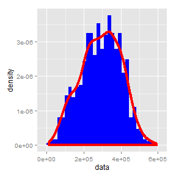

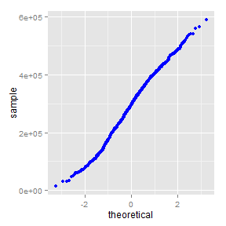

```r
EDA.hist(Water$Alkalinity)
EDA.qq(Water$Alkalinity)
```

> SOLUTION: The distribution of Alkalinity across groundwater wells in Minnesota is approximately normal with a mean of `2.9068 &times; 10<sup>5</sup>` and a standard deviation of `1.0833 &times; 10<sup>5</sup>`.
- Find the 95% \( t \) confidence interval for the mean \( \mu \) of alkalinity levels in Minnesota wells.

```r
test <- t.test(Water$Alkalinity)
```

> SOLUTION: We are 95% confident that the mean \( \mu \) of alkalinity levels in Minnesota wells is within (`2.8358 &times; 10<sup>5</sup>`, `2.9779 &times; 10<sup>5</sup>`).
- Find the 95% bootstrap percentile and bootstrap \( t \) confidence intervals for the mean alkalinity level and compare the results. Which confidence interval will you report?

**Prob11** Consider the babies born in Texas in 2004 (`TXBirths2004`). We will compare the weights of babies born to nonsmokers and smokers.

```r
Texas <- importData("TXBirths2004")
head(Texas)
```

```
  ID MothersAge Smoker Gender Weight Gestation Number Multiple
1  1      20-24     No   Male   3033        39      1       No
2  2      20-24     No   Male   3232        40      1       No
3  3      25-29     No Female   3317        37      1       No
4  4      25-29     No Female   2560        36      1       No
5  5      15-19     No Female   2126        37      1       No
6  6      30-34     No Female   2948        38      1       No
```

- How many nonsmokers and smokers are there in this data set?

```r
smokers <- sum(Texas$Smoker == "Yes")
nonsmokers <- sum(Texas$Smoker == "No")
```

> SOLUTION: In this data set of `1587` texans, there are `90` smokers and `1497` non-smokers.
- Create exploratory plots of the weights for the two groups and comment on the distributions.

```r
ggplot(data = Texas, aes(x = Weight)) + geom_histogram() + facet_grid(Smoker ~
    .)
```

```
stat_bin: binwidth defaulted to range/30. Use 'binwidth = x' to adjust
this.
```

```
stat_bin: binwidth defaulted to range/30. Use 'binwidth = x' to adjust
this.
```

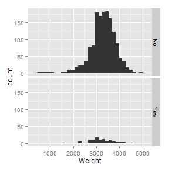

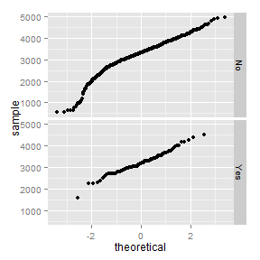

```r
ggplot(data = Texas, aes(sample = Weight)) + stat_qq() + facet_grid(Smoker ~
    .)
smokersEDA <- c(mean(Texas$Weight[Texas$Smoker == "Yes"]), sd(Texas$Weight[Texas$Smoker ==
    "Yes"]))
nonsmokersEDA <- c(mean(Texas$Weight[Texas$Smoker == "No"]), sd(Texas$Weight[Texas$Smoker ==
    "No"]))
```

> SOLUTION: The distribution of smokers is approximately normal with a mean of `3205.9889` and a standard-deviation of `504.2439`. The distribution of weights among non-smokers is a little bit skewed to the left, with a mean of `3287.4937` and a standard-deviation of `554.4829`.
- Compute the 95% confidence interval for the difference in means using the formula \( t \), bootstrap percentile, and bootstrap \( t \) methods and compare your results. Which interval would you report?

```r
Weight.Smokers <- subset(Texas, select = Weight, Smoker == "Yes", drop = TRUE)
Weight.Non <- subset(Texas, select = Weight, Smoker == "No", drop = TRUE)
thetahat <- mean(Weight.Smokers) - mean(Weight.Non)
nx <- length(Weight.Smokers)
ny <- length(Weight.Non)
SE <- sqrt(var(Weight.Smokers)/nx + var(Weight.Non)/ny)
N <- 10^4
Tstar <- numeric(N)
DM <- numeric(N)
set.seed(1)
for (i in 1:N) {
    bootx <- sample(Weight.Smokers, nx, replace = TRUE)
    booty <- sample(Weight.Non, ny, replace = TRUE)
    Tstar[i] <- (mean(bootx) - mean(booty) - thetahat)/sqrt(var(bootx)/nx +
        var(booty)/ny)
    DM[i] <- mean(bootx) - mean(booty)
}
CItboot <- thetahat - quantile(Tstar, c(0.975, 0.025)) * SE
names(CItboot) <- NULL
CItboot
```

```
[1] -189.4   28.8
```

```r
CIperct <- quantile(DM, c(0.025, 0.975))
CIperct
```

```
   2.5%   97.5%
-188.63   26.02
```

```r
t.test(Weight.Smokers, Weight.Non)$conf
```

```
[1] -190.69   27.68
attr(,"conf.level")
[1] 0.95
```

> SOLUTION: The 95% bootstrap \( t \) interval for the difference in means is (`-189.4169`, `28.8041`). For comparison, the formula \( t \) interval is (`-190.6915`, `27.682`) and the bootstrap percentile interval is (`-188.6289`, `26.0167`).
- Modify your result from the previous question to obtain a one-sided 95% \( t \) confidence interval (hypothesizing that babies born to nonsmokers weigh more than babies born to smokers).

```r
CItboot <- thetahat - quantile(Tstar, 0.975) * SE
names(CItboot) <- NULL
CItboot
```

```
[1] -189.4
```

```r
test <- t.test(Weight.Smokers, Weight.Non, alternative = "g")
```